# Data & Distributions

## Aims

Assumptions of parametric tests based on the normal distribution

Understand the assumption of normality

- Graphical displays
- Skew
- Kurtosis
- Normality tests

Understand homogeneity of variance

- Levene’s test

Know how to correct problems in the data

- Log, square root and reciprocal transformations

## Assumptions

Parametric tests based on the normal distribution assume:

- Normally distributed
  - Sampling distribution
  - Residuals
- Homogeneity of variance
- Interval or ratio level data
- Independent scores

## Assessing Normality

We don’t have access to the sampling distribution so we usually test the observed data

Central limit theorem

- If N > 30, the sampling distribution is normal anyway

Graphical displays

- Q-Q plot
- Histogram

Values of skew/kurtosis

- 0 in a normal distribution
- Convert to z (by dividing value by SE)

Kolmogorov-Smirnov test

- Tests if data differ from a normal distribution
- Significant = non-normal data
- Non-significant = normal data

### Normality Example 1

A biologist was worried about the potential health effects of music festivals. The biologist went to The Download Music Festival and measured the hygiene of 810 concert-goers over the three days of the festival.

Hygiene was measured using a standardized technique:  
Score ranged from 0 to 4

- 0 = you smell like a corpse rotting up a skunk’s arse
- 4 = you smell of sweet roses on a fresh spring day

#### The Q-Q Plot

To draw a Q-Q plot of the hygiene scores for day 1 of the music festival:

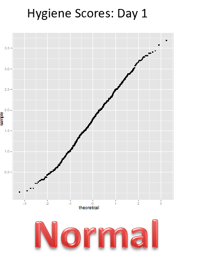

```r
qqplot.day1 <- qplot(sample = dlf$day1, stat = "qq")
qqplot.day1
```

To draw a Q-Q plot of the hygiene scores for day 2 of the music festival:

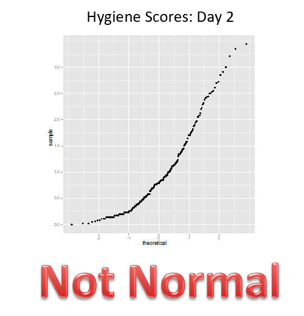

```r
qqplot.day2 <- qplot(sample = dlf$day2, stat = "qq")
qqplot.day2
```

#### Assessing Skew and Kurtosis

We can use *describe()* and *stat.desc()* with more than one variable at the same time using *cbind()*:

```r
describe(cbind(dlf$day1, dlf$day2, dlf$day3))

stat.desc(cbind(dlf$day1, dlf$day2, dlf$day3), basic = FALSE,
    norm = TRUE)
```

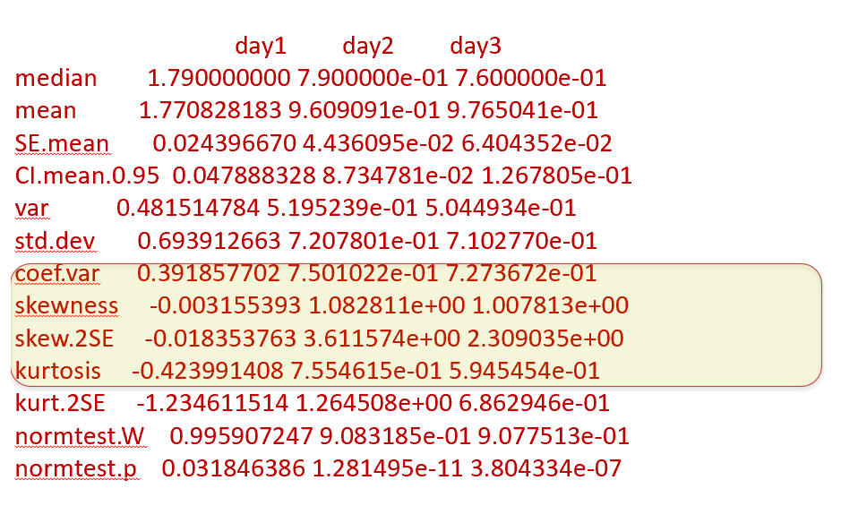

### Normality Example 2

Performance on statistics exam

Participants: N = 100 students

Measures

- **Exam:** first-year exam scores as a percentage
- **Computer:** measure of computer literacy, %
- **Lecture:** percentage of lectures attended
- **Numeracy:** a measure of numerical ability out of 15
- **Uni:** whether the student attended Sussex University or Duncetown University

#### Assessing Normality

##### Shapiro-Wilk tests

Shapiro-Wilk test for normality for exam and numeracy for whole sample: If p-value > 0.05, implies that the distribution of the data are not significantly different from normal distribution. In other words, we can assume the normality. (good)

```r
shapiro.test(rexam$exam)
shapiro.test(rexam$numeracy)
```

**Output:**

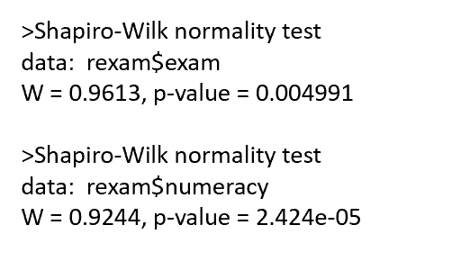

Shapiro-Wilk test for exam and numeracy split by university:

```r
by(rexam$exam, rexam$uni, shapiro.test)
by(rexam$numeracy, rexam$uni, shapiro.test)
```

**Output for exam:**

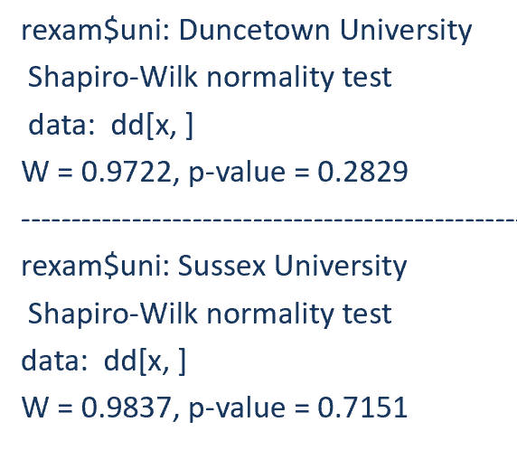

**Output for numeracy:**

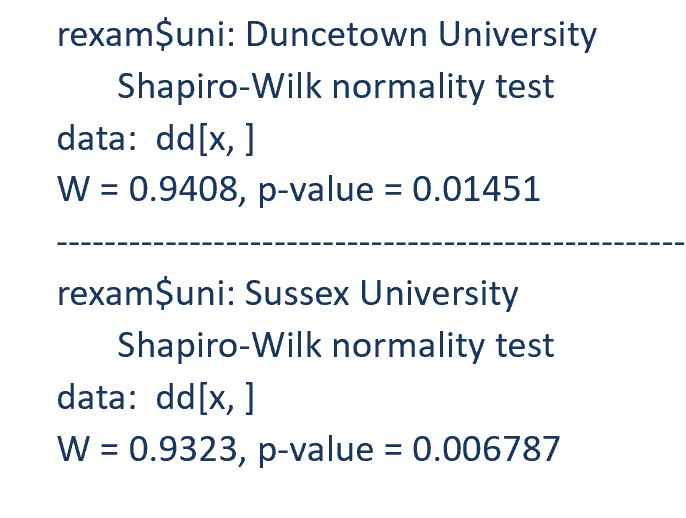

##### Q-Q Plots

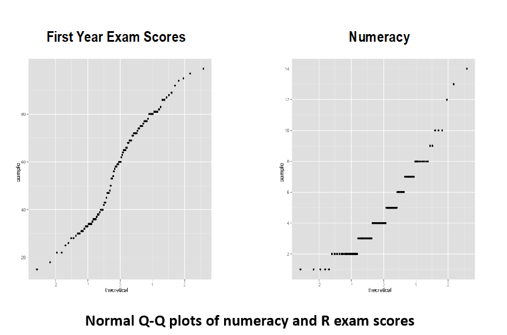

## Assessing Homogeneity of Variance

Graphs

Levene’s test

- Tests if variances in different groups are the same
- Significant = variances not equal (bad)
- Non-significant = variances are equal (good)

### Graphs

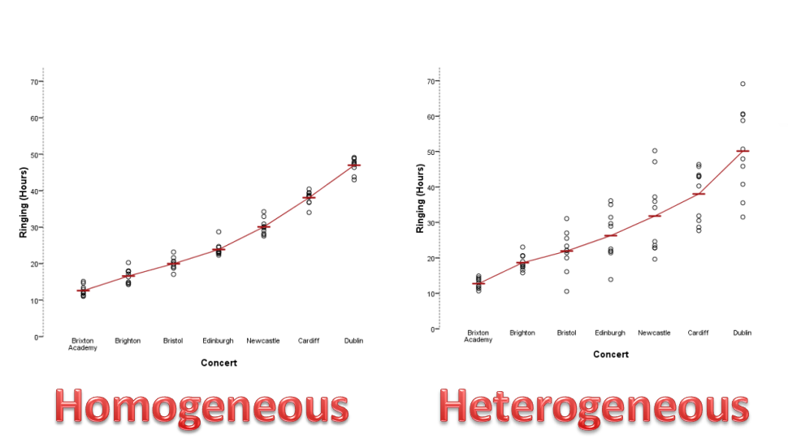

### Assessing Homogeneity of Variance with R

Use the leveneTest() function from the car package. Levene’s test for the exam and numeracy scores:

```r
leveneTest(rexam$exam, rexam$uni)
leveneTest(rexam$numeracy, rexam$uni)
```

**Output:**

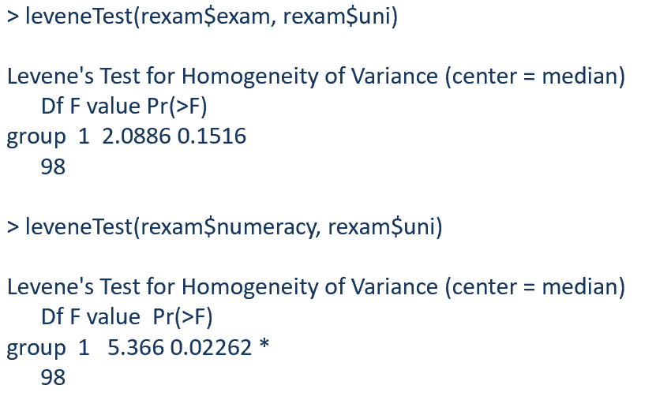

## Correcting Data Problems

**Log transformation (log(Xi)):** Reduce positive skew.

```r
dlf$logday1 <- log(dlf$day1)
```

**Square root transformation (√Xi):** Also reduces positive skew. Can also be useful for stabilizing variance.

```r
dlf$sqrtday1 <- sqrt(day1)
```

**Reciprocal transformation (1/ Xi):** Dividing 1 by each score also reduces the impact of large scores. This transformation reverses the scores; you can avoid this by reversing the scores before the transformation, 1/(XHighest – Xi).

```r
dlf$recday1 <- 1/(dlf$day1)
```

### The Effect of Transformations

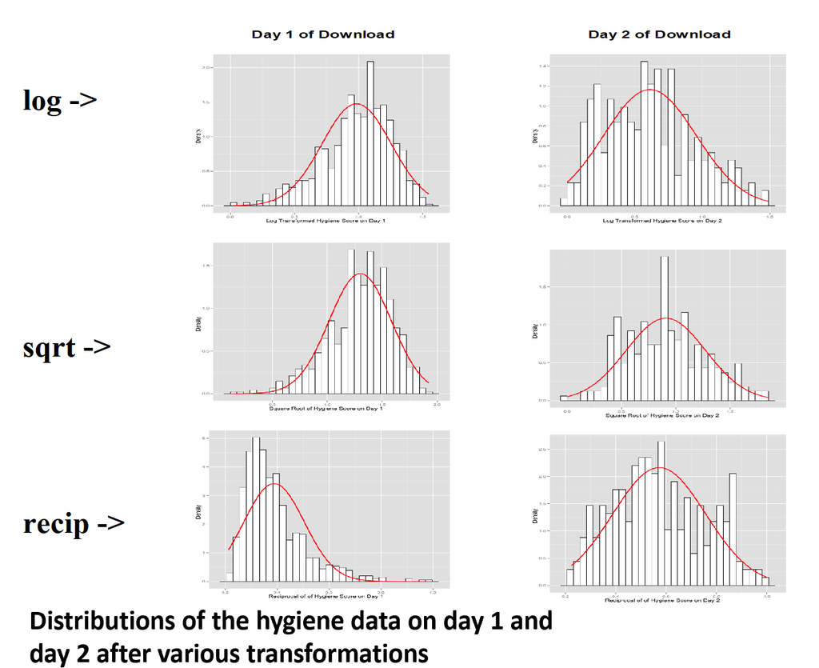

### To Transform … Or Not

Transforming the data helps as often as it hinders the accuracy of F (Games & Lucas, 1966)

Games (1984):

- The central limit theorem: sampling distribution will be normal in samples > 40 anyway.
- Transforming the data changes the hypothesis being tested
  - E.g. when using a log transformation and comparing means, you change from comparing arithmetic means to comparing geometric means
- In small samples it is tricky to determine normality one way or another.
- The consequences for the statistical model of applying the ‘wrong’ transformation could be worse than the consequences of analysing the untransformed scores.